# VSP5600 Performance Analysis

## 1. Configuration & Global Constants

**IMPORTANT:** Update these values when analyzing a different dataset.

```
ROOT_DIR: /Users/visubramaniam/Downloads/PerformanceExportAnalysis
OUT_FOLDER: /Users/visubramaniam/Downloads/PerformanceExportAnalysis/out_20260108_085004
BASE_PATH: /Users/visubramaniam/Downloads/PerformanceExportAnalysis/out_20260108_085004
Data folder exists: False
Images folder: /Users/visubramaniam/Downloads/PerformanceExportAnalysis/images
```

## 2. Import Libraries

```
All libraries imported successfully!
Images will be saved to: /Users/visubramaniam/Downloads/PerformanceExportAnalysis/images
```

## 3. Function Definitions

### 3.1 File Operations

```
File operation functions defined (with recursive ZIP extraction).
```

### 3.2 CSV Data Loading Functions

### 3.3 Data Filtering Functions

```
Data filtering functions defined (including adaptive threshold filtering).
```

## 4. Data Extraction

Extract zip files and prepare data folders.

```
Looking for main ZIP file: out_VSP5600_65535_Performance_Data.20251222.0923.zip
  Path: /Users/visubramaniam/Downloads/PerformanceExportAnalysis/out_VSP5600_65535_Performance_Data.20251222.0923.zip
  Exists: True

✅ Found main ZIP file (204.8 MB)
   Will extract to: /Users/visubramaniam/Downloads/PerformanceExportAnalysis/out_20260108_085004
```

```
Created output folder: /Users/visubramaniam/Downloads/PerformanceExportAnalysis/out_20260108_085004

Step 1: Extracting main ZIP file: out_VSP5600_65535_Performance_Data.20251222.0923.zip
  -> Extracted to: /Users/visubramaniam/Downloads/PerformanceExportAnalysis/out_20260108_085004
  Archived: out_VSP5600_65535_Performance_Data.20251222.0923.zip -> /Users/visubramaniam/Downloads/PerformanceExportAnalysis/archive/out_VSP5600_65535_Performance_Data.20251222.0923.zip

============================================================
Step 2: Extracting nested ZIP files in data folder...
============================================================

Iteration 1: Found 59 ZIP file(s)
  Extracting: URLU_dat.ZIP
    -> URLU_dat
  Extracting: RemoteCopy_dat.ZIP
    -> RemoteCopy_dat
  Extracting: PhyMPU_dat.ZIP
    -> PhyMPU_dat
  Extracting: PhyProc_dat.ZIP
    -> PhyProc_dat
  Extracting: PhyPG_dat.ZIP
    -> PhyPG_dat
  Extracting: UniversalReplicator_dat.ZIP
    -> UniversalReplicator_dat
  Extracting: URJNL_dat.ZIP
    -> URJNL_dat
  Extracting: PhyProcDetail_dat.ZIP
    -> PhyProcDetail_dat
  Extracting: PG_dat.ZIP
    -> PG_dat
  Extracting: Port_dat.ZIP
    -> Port_dat
  Extracting: PhyLDEV_dat.ZIP
    -> PhyLDEV_dat
  Extracting: LU_dat.ZIP
    -> LU_dat
  Extracting: RCLU_dat.ZIP
    -> RCLU_dat
  Extracting: URLDEV_dat/URLDEV_Write_Hit.ZIP
    -> URLDEV_dat/URLDEV_Write_Hit
  Extracting: URLDEV_dat/URLDEV_Initial_Copy_Hit.ZIP
```

[output cut: 78 more lines]

```
    -> RCLDEV_dat/RCLDEV_All_Write
  Extracting: RCLDEV_dat/RCLDEV_Initial_Copy_RIO.ZIP
    -> RCLDEV_dat/RCLDEV_Initial_Copy_RIO
  Extracting: RCLDEV_dat/RCLDEV_RIO_Error.ZIP
    -> RCLDEV_dat/RCLDEV_RIO_Error
  Extracting: RCLDEV_dat/RCLDEV_Pair_Synchronized.ZIP
    -> RCLDEV_dat/RCLDEV_Pair_Synchronized
  Extracting: RCLDEV_dat/RCLDEV_Update_Copy_RIO.ZIP
    -> RCLDEV_dat/RCLDEV_Update_Copy_RIO
  Extracting: RCLDEV_dat/RCLDEV_All_RIO.ZIP
    -> RCLDEV_dat/RCLDEV_All_RIO

Total nested ZIPs extracted: 59

Extraction complete!
```

```
Checking data folder: /Users/visubramaniam/Downloads/PerformanceExportAnalysis/out_20260108_085004
Exists: True

Subfolders found:
  📁 LDEVEachOfCU_dat
  📁 LU_dat
  📁 PG_dat
  📁 PhyExLDEV_dat
  📁 PhyLDEV_dat
  📁 PhyMPU_dat
  📁 PhyPG_dat
  📁 PhyProcDetail_dat
  📁 PhyProc_dat
  📁 Port_dat
  📁 RCLDEV_dat
  📁 RCLU_dat
  📁 RemoteCopy_dat
  📁 URJNL_dat
  📁 URLDEV_dat
  📁 URLU_dat
  📁 UniversalReplicator_dat

Merged output folder: /Users/visubramaniam/Downloads/PerformanceExportAnalysis/merged
```

## 5. Data Loading & Processing

### 5.1 Cache Metrics (Write Pending Rate & Cache Usage Rate)

```
Write Pending Rate: 1440 rows (using column: ALL)
Cache Usage Rate: 1440 rows (using column: ALL)
Merged Cache Metrics: 1440 rows
```

|  | time | Write_Pending_Rate | Cache_Usage_Rate |
| --- | --- | --- | --- |
| count | 1440 | 1440.000000 | 1440.000000 |
| mean | 2025-12-19 02:17:30 | 9.991667 | 70.378472 |
| min | 2025-12-18 14:18:00 | -4.000000 | -4.000000 |
| 25% | 2025-12-18 20:17:45 | 8.000000 | 74.000000 |
| 50% | 2025-12-19 02:17:30 | 10.000000 | 76.000000 |
| 75% | 2025-12-19 08:17:15 | 11.000000 | 78.000000 |
| max | 2025-12-19 14:17:00 | 26.000000 | 83.000000 |
| std | NaN | 5.597074 | 20.120981 |

### 5.2 MPU Usage Data

```
MPU Raw Data: (1440, 82)
MPU columns: 80
```

```
Sample mpu_cols: ['MPU-010.MP010-00', 'MPU-010.MP010-01', 'MPU-010.MP010-02']

MPU groups: 4
  MPU-010: 20 cores
  MPU-020: 20 cores
  MPU-110: 20 cores
  MPU-120: 20 cores
```

```
MPU averages shape: (1440, 5)
Columns: ['time', 'MPU-010_avg', 'MPU-020_avg', 'MPU-110_avg', 'MPU-120_avg']
Merged MPU with Write Pending shape: (1440, 6)
```

|  | time | MPU-010_avg | MPU-020_avg | MPU-110_avg | MPU-120_avg | Write_Pending_Rate |
| --- | --- | --- | --- | --- | --- | --- |
| count | 1440 | 1440.000000 | 1440.000000 | 1440.000000 | 1440.000000 | 1440.000000 |
| mean | 2025-12-19 02:17:30 | 42.501979 | 50.033368 | 47.691632 | 44.881076 | 9.991667 |
| min | 2025-12-18 14:18:00 | -4.000000 | -4.000000 | -4.000000 | -4.000000 | -4.000000 |
| 25% | 2025-12-18 20:17:45 | 42.350000 | 46.250000 | 44.750000 | 42.900000 | 8.000000 |
| 50% | 2025-12-19 02:17:30 | 43.850000 | 48.500000 | 46.550000 | 44.650000 | 10.000000 |
| 75% | 2025-12-19 08:17:15 | 44.950000 | 52.950000 | 49.862500 | 46.800000 | 11.000000 |
| max | 2025-12-19 14:17:00 | 56.550000 | 78.900000 | 77.550000 | 75.300000 | 26.000000 |
| std | NaN | 7.460902 | 11.066828 | 10.174514 | 9.042645 | 5.597074 |

### 5.3 HIE Metrics (HIE ISW & MPU HIE)

```
HIE_ISW: (1440, 18)
MPU_HIE: (1440, 10)
```

|  | No. | time | MPU-010.HIE-01G | MPU-010.HIE-01C | MPU-020.HIE-02G | MPU-020.HIE-02C | MPU-110.HIE-11G | MPU-110.HIE-11C | MPU-120.HIE-12G | MPU-120.HIE-12C |
| --- | --- | --- | --- | --- | --- | --- | --- | --- | --- | --- |
| count | 1440.000000 | 1440 | 1440.000000 | 1440.000000 | 1440.000000 | 1440.000000 | 1440.000000 | 1440.000000 | 1440.000000 | 1440.000000 |
| mean | 720.500000 | 2025-12-19 02:17:30 | 16.440278 | 15.933333 | 16.952083 | 16.899306 | 16.639583 | 17.241667 | 15.994444 | 15.446528 |
| min | 1.000000 | 2025-12-18 14:18:00 | -4.000000 | -4.000000 | -4.000000 | -4.000000 | -4.000000 | -4.000000 | -4.000000 | -4.000000 |
| 25% | 360.750000 | 2025-12-18 20:17:45 | 14.000000 | 14.000000 | 14.000000 | 14.000000 | 14.000000 | 15.000000 | 13.000000 | 13.000000 |
| 50% | 720.500000 | 2025-12-19 02:17:30 | 17.000000 | 16.000000 | 16.000000 | 16.000000 | 16.000000 | 17.000000 | 16.000000 | 15.000000 |
| 75% | 1080.250000 | 2025-12-19 08:17:15 | 20.000000 | 19.000000 | 20.000000 | 20.000000 | 20.000000 | 20.000000 | 18.000000 | 18.000000 |
| max | 1440.000000 | 2025-12-19 14:17:00 | 44.000000 | 43.000000 | 51.000000 | 52.000000 | 50.000000 | 51.000000 | 48.000000 | 49.000000 |
| std | 415.836506 | NaN | 6.897485 | 6.871682 | 8.224681 | 8.234168 | 7.628079 | 7.714228 | 7.573589 | 7.559166 |

### 5.4 Port Response Data

```
Port Response: (1440, 30)
Port columns: 28
```

```
Filtering ports with consecutive readings > threshold (starting at 10000 µs)...
  ✓ Found 8 items at threshold 10000.00 (iteration 1)
Ports with 5+ consecutive readings > 10000 µs: 8
Filtered port data shape: (1440, 9)
```

|  | time | CL3-A | CL3-B | CL1-D | CL3-D | CL4-A | CL4-B | CL2-D | CL4-D |
| --- | --- | --- | --- | --- | --- | --- | --- | --- | --- |
| count | 1440 | 1436.000000 | 1436.000000 | 1436.000000 | 1436.000000 | 1436.000000 | 1436.000000 | 1436.000000 | 1436.000000 |
| mean | 2025-12-19 02:17:30 | 1358.094708 | 1365.497214 | 30862.288301 | 23233.559889 | 1316.340529 | 1337.172006 | 25142.761142 | 34595.563370 |
| min | 2025-12-18 14:18:00 | 142.000000 | 156.000000 | 16819.000000 | 16941.000000 | 128.000000 | 157.000000 | 16909.000000 | 16840.000000 |
| 25% | 2025-12-18 20:17:45 | 320.750000 | 320.000000 | 18385.500000 | 18355.250000 | 296.000000 | 313.000000 | 18346.250000 | 18386.750000 |
| 50% | 2025-12-19 02:17:30 | 423.500000 | 423.000000 | 18881.500000 | 18800.500000 | 402.000000 | 415.000000 | 18815.500000 | 18921.500000 |
| 75% | 2025-12-19 08:17:15 | 671.500000 | 678.000000 | 20517.750000 | 19951.250000 | 653.000000 | 665.500000 | 20253.250000 | 22319.000000 |
| max | 2025-12-19 14:17:00 | 43280.000000 | 42233.000000 | 571680.000000 | 171386.000000 | 41645.000000 | 42403.000000 | 223974.000000 | 854768.000000 |
| std | NaN | 2928.421938 | 2924.357122 | 46266.616660 | 14033.154789 | 2867.576806 | 2880.774758 | 19055.108051 | 55111.724552 |

### 5.5 LDEV IOPS Data

```
Loading Read IOPS...
Found 2 files: ['LDEV_Read_IOPS00.csv', 'LDEV_Read_IOPS01.csv']
  Shape: (1440, 193)

Loading Write IOPS...
Found 2 files: ['LDEV_Write_IOPS00.csv', 'LDEV_Write_IOPS01.csv']
  Shape: (1440, 193)
```

```
Common LDEV columns: 192
Read IOPS after filtering: 1345 rows, unique times: 1345
Write IOPS after filtering: 1345 rows, unique times: 1345
After deduplication - Read: 1345 rows, Write: 1345 rows
LDEVs with activity in both Read and Write: 160
```

```
df_read_iops_filtered shape: (1345, 193)
df_write_iops_filtered shape: (1345, 193)
df_read_iops_filtered time unique: 1345
df_write_iops_filtered time unique: 1345
active_iops_ldevs count: 160

Check for duplicate times in read filtered:
  Total rows: 1345
  Unique times: 1345
  Avg rows per time: 1.00
```

|  | time | 00:00:C0(1-3) | 00:00:C1(1-1) | 00:00:C2(1-5) | 00:00:C3X | 00:00:C4X | 00:00:C5X | 00:00:C6X | 00:00:C7X | 00:00:C8X | ... | 00:01:76X | 00:01:77X | 00:01:78X | 00:01:79X | 00:01:7AX | 00:01:7BX | 00:01:7CX | 00:01:7DX | 00:01:7EX | 00:01:7FX |
| --- | --- | --- | --- | --- | --- | --- | --- | --- | --- | --- | --- | --- | --- | --- | --- | --- | --- | --- | --- | --- | --- |
| count | 1345 | 1345.0 | 1345.0 | 1345.0 | 1345.000000 | 1345.000000 | 1345.000000 | 1345.000000 | 1345.000000 | 1345.000000 | ... | 1052.000000 | 1052.000000 | 1052.0 | 1052.0 | 1052.0 | 1052.0 | 1052.0 | 1052.0 | 1052.0 | 1052.0 |
| mean | 2025-12-19 03:03:14.408922112 | 0.0 | 0.0 | 0.0 | 10.175465 | 66.060967 | 117.631227 | 890.125651 | 71.745725 | 182.599257 | ... | 1.447719 | 61.038023 | 0.0 | 0.0 | 0.0 | 0.0 | 0.0 | 0.0 | 0.0 | 0.0 |
| min | 2025-12-18 15:50:00 | 0.0 | 0.0 | 0.0 | 2.000000 | 1.000000 | 5.000000 | 3.000000 | 3.000000 | 5.000000 | ... | 0.000000 | 0.000000 | 0.0 | 0.0 | 0.0 | 0.0 | 0.0 | 0.0 | 0.0 | 0.0 |
| 25% | 2025-12-18 21:26:00 | 0.0 | 0.0 | 0.0 | 2.000000 | 6.000000 | 13.000000 | 113.000000 | 6.000000 | 20.000000 | ... | 1.000000 | 1.000000 | 0.0 | 0.0 | 0.0 | 0.0 | 0.0 | 0.0 | 0.0 | 0.0 |
| 50% | 2025-12-19 03:02:00 | 0.0 | 0.0 | 0.0 | 2.000000 | 9.000000 | 21.000000 | 301.000000 | 13.000000 | 51.000000 | ... | 1.000000 | 1.000000 | 0.0 | 0.0 | 0.0 | 0.0 | 0.0 | 0.0 | 0.0 | 0.0 |
| 75% | 2025-12-19 08:41:00 | 0.0 | 0.0 | 0.0 | 2.000000 | 32.000000 | 48.000000 | 696.000000 | 40.000000 | 163.000000 | ... | 1.000000 | 2.000000 | 0.0 | 0.0 | 0.0 | 0.0 | 0.0 | 0.0 | 0.0 | 0.0 |
| max | 2025-12-19 14:17:00 | 0.0 | 0.0 | 0.0 | 2725.000000 | 2581.000000 | 7014.000000 | 8209.000000 | 6512.000000 | 7500.000000 | ... | 12.000000 | 7927.000000 | 0.0 | 0.0 | 0.0 | 0.0 | 0.0 | 0.0 | 0.0 | 0.0 |
| std | NaN | 0.0 | 0.0 | 0.0 | 132.479992 | 181.031751 | 446.422595 | 1615.846961 | 255.590617 | 397.947436 | ... | 1.920921 | 332.445911 | 0.0 | 0.0 | 0.0 | 0.0 | 0.0 | 0.0 | 0.0 | 0.0 |

8 rows × 193 columns

### 5.6 LDEV Transfer Rate Data

```
Loading Transfer Rate (all CUs)...
Found 2 files: ['LDEV_TransRate00.csv', 'LDEV_TransRate01.csv']
  Combined Shape: (1440, 193)
  Columns: 192 LDEVs
```

```
Filtering LDEVs with high transfer rates (starting at 100000 KB/s)...
  ✓ Found 67 items at threshold 100000.00 (iteration 1)
High transfer rate LDEVs: 67 (threshold: 100000 KB/s)
  Example LDEVs: ['00:00:C5X', '00:00:C6X', '00:00:C7X', '00:00:C9X', '00:00:CAX', '00:00:CBX', '00:00:CCX', '00:00:CDX', '00:00:CEX', '00:00:CFX']...
```

|  | time | 00:00:C0(1-3) | 00:00:C1(1-1) | 00:00:C2(1-5) | 00:00:C3X | 00:00:C4X | 00:00:C5X | 00:00:C6X | 00:00:C7X | 00:00:C8X | ... | 00:01:76X | 00:01:77X | 00:01:78X | 00:01:79X | 00:01:7AX | 00:01:7BX | 00:01:7CX | 00:01:7DX | 00:01:7EX | 00:01:7FX |
| --- | --- | --- | --- | --- | --- | --- | --- | --- | --- | --- | --- | --- | --- | --- | --- | --- | --- | --- | --- | --- | --- |
| count | 1440 | 1440.000000 | 1440.000000 | 1440.000000 | 1440.000000 | 1440.000000 | 1440.000000 | 1440.000000 | 1440.000000 | 1440.000000 | ... | 1127.000000 | 1127.000000 | 1127.000000 | 1127.000000 | 1127.000000 | 1127.000000 | 1127.000000 | 1127.000000 | 1127.000000 | 1127.000000 |
| mean | 2025-12-19 02:17:30 | -0.257639 | -0.257639 | -0.257639 | 496.542361 | 6506.442361 | 27223.201389 | 62850.079167 | 15687.893750 | 42473.786806 | ... | 233.100266 | 7579.899734 | 8.096717 | 6.293700 | 7.173913 | 2.406389 | 3.096717 | 2.700089 | -0.260870 | -0.260870 |
| min | 2025-12-18 14:18:00 | -4.000000 | -4.000000 | -4.000000 | -4.000000 | -4.000000 | -4.000000 | -4.000000 | -4.000000 | -4.000000 | ... | -4.000000 | -4.000000 | -4.000000 | -4.000000 | -4.000000 | -4.000000 | -4.000000 | -4.000000 | -4.000000 | -4.000000 |
| 25% | 2025-12-18 20:17:45 | 0.000000 | 0.000000 | 0.000000 | 160.750000 | 2156.750000 | 21799.750000 | 13548.500000 | 5261.000000 | 37621.500000 | ... | 83.000000 | 85.000000 | 7.000000 | 6.000000 | 6.000000 | 1.000000 | 2.000000 | 2.000000 | 0.000000 | 0.000000 |
| 50% | 2025-12-19 02:17:30 | 0.000000 | 0.000000 | 0.000000 | 166.000000 | 3006.500000 | 24399.500000 | 33105.000000 | 11376.500000 | 40844.500000 | ... | 83.000000 | 86.000000 | 8.000000 | 6.000000 | 6.000000 | 2.000000 | 3.000000 | 2.000000 | 0.000000 | 0.000000 |
| 75% | 2025-12-19 08:17:15 | 0.000000 | 0.000000 | 0.000000 | 181.000000 | 5889.250000 | 26980.250000 | 67859.500000 | 20327.750000 | 45631.250000 | ... | 83.000000 | 94.000000 | 10.000000 | 7.000000 | 10.000000 | 3.000000 | 4.000000 | 3.000000 | 0.000000 | 0.000000 |
| max | 2025-12-19 14:17:00 | 0.000000 | 0.000000 | 0.000000 | 109095.000000 | 120301.000000 | 342308.000000 | 882521.000000 | 375883.000000 | 348338.000000 | ... | 4541.000000 | 528191.000000 | 39.000000 | 24.000000 | 34.000000 | 30.000000 | 189.000000 | 189.000000 | 0.000000 | 0.000000 |
| std | NaN | 0.979078 | 0.979078 | 0.979078 | 4821.401808 | 12710.388760 | 23970.876793 | 100047.698102 | 23148.526223 | 20710.462397 | ... | 816.860663 | 38011.999608 | 4.334633 | 3.369989 | 4.106045 | 2.970529 | 6.184440 | 6.160280 | 0.985375 | 0.985375 |

8 rows × 193 columns

### 5.7 LDEV Response Data

```
Loading all LDEV Response files (hex suffixes 00-FF)...
Found 2 files: ['LDEV_Response00.csv', 'LDEV_Response01.csv']
  Combined Shape: (1440, 193)
  Columns: 192 LDEVs
```

```
Filtering LDEVs with consecutive readings > threshold (starting at 1000 µs)...
  ✓ Found 127 items at threshold 1000.00 (iteration 1)
LDEVs with 5+ consecutive readings > 1000 µs: 127
  Example LDEVs: ['00:00:C4X', '00:00:C5X', '00:00:C6X', '00:00:C8X', '00:00:C9X', '00:00:CAX', '00:00:CCX', '00:00:CDX', '00:00:CEX', '00:00:CFX']...
```

```
Total IOPS shape: (1345, 161)
Unique timestamps in merged data: 1345
Filtering LDEVs with IOPS >= threshold (starting at 5000)...
  ✓ Found 160 items at threshold 5000.00 (iteration 1)
LDEVs with IOPS >= 5000: 160
Filtering read-heavy LDEVs (>= 60% read)...
  ✓ Found 158 items at threshold 60.00 (iteration 1)
Read-heavy LDEVs (>= 60% read): 158
```

```
Filtering LDEVs with IOPS >= threshold (starting at 5000)...
  ✓ Found 64 items at threshold 5000.00 (iteration 1)
LDEVs with IOPS >= 5000: 64
Filtering read-heavy LDEVs (>= 60% read)...
  ✓ Found 64 items at threshold 60.00 (iteration 1)
Read-heavy LDEVs (>= 60% read): 64
```

|  | time | 00:01:5EX | 00:01:5CX | 00:01:0DX | 00:00:D9X | 00:00:E1X | 00:01:01X | 00:00:C8X | 00:00:E8X | 00:00:D8X | ... | 00:00:D3X | 00:01:37X | 00:00:F6X | 00:01:10X | 00:01:03X | 00:00:EFX | 00:01:44X | 00:00:E2X | 00:00:F2X | 00:01:1DX |
| --- | --- | --- | --- | --- | --- | --- | --- | --- | --- | --- | --- | --- | --- | --- | --- | --- | --- | --- | --- | --- | --- |
| count | 1345 | 1345.000000 | 1345.000000 | 1345.000000 | 1345.000000 | 1345.000000 | 1345.000000 | 1345.000000 | 1345.000000 | 1345.000000 | ... | 1345.000000 | 1345.000000 | 1345.000000 | 1345.000000 | 1345.000000 | 1345.000000 | 1345.000000 | 1345.000000 | 1345.000000 | 1345.000000 |
| mean | 2025-12-19 03:03:14.408922112 | 64.095568 | 8.048467 | 21.533937 | 9.715506 | 3.578563 | 58.192214 | 12.402716 | 62.715573 | 17.686042 | ... | 72.488298 | 10.164923 | 50.249713 | 32.291664 | 60.105055 | 34.331915 | 47.804218 | 13.658913 | 47.282043 | 76.265932 |
| min | 2025-12-18 15:50:00 | 0.000000 | 0.000000 | 0.000000 | 0.436681 | 0.085690 | 0.000000 | 0.831025 | 0.400000 | 1.834862 | ... | 26.321586 | 0.000000 | 3.225806 | 0.000000 | 10.738255 | 6.896552 | 0.000000 | 1.420455 | 0.225734 | 0.000000 |
| 25% | 2025-12-18 21:26:00 | 0.000000 | 0.000000 | 6.172840 | 3.125000 | 0.626959 | 42.372881 | 2.790698 | 33.333333 | 6.398104 | ... | 61.849711 | 3.448276 | 25.000000 | 8.635097 | 40.000000 | 23.076923 | 10.000000 | 3.370787 | 19.565217 | 95.025907 |
| 50% | 2025-12-19 03:02:00 | 99.544419 | 0.000000 | 13.829787 | 5.555556 | 1.131687 | 66.666667 | 6.727038 | 66.666667 | 9.815951 | ... | 80.807692 | 8.333333 | 33.333333 | 21.969697 | 62.886598 | 30.075188 | 50.000000 | 5.243446 | 33.333333 | 97.710438 |
| 75% | 2025-12-19 08:41:00 | 99.948160 | 0.000000 | 25.000000 | 8.571429 | 2.135231 | 83.333333 | 16.171875 | 97.603946 | 19.727891 | ... | 85.544500 | 14.285714 | 85.714286 | 60.425532 | 81.087763 | 36.000000 | 66.666667 | 18.430034 | 83.928571 | 98.729890 |
| max | 2025-12-19 14:17:00 | 99.979339 | 99.984069 | 99.170847 | 97.737069 | 87.885867 | 99.909747 | 80.828165 | 99.993828 | 95.307478 | ... | 98.251886 | 99.817968 | 99.861159 | 95.522621 | 99.901283 | 99.325084 | 99.989176 | 97.031228 | 99.917184 | 99.828669 |
| std | NaN | 44.739490 | 18.777412 | 24.948261 | 15.362902 | 9.015557 | 34.536285 | 14.678595 | 33.592382 | 19.902667 | ... | 18.010913 | 11.111323 | 30.898246 | 29.273510 | 23.642334 | 20.066035 | 32.559055 | 16.787003 | 33.232617 | 40.547356 |

8 rows × 65 columns

```
Summary of IOPS-based filtering:
  - Active IOPS LDEVs: 160
  - High IOPS LDEVs: 64
  - Read-heavy LDEVs: 64
```

```
Loading Read Response...
Found 2 files: ['LDEV_Read_Response00.csv', 'LDEV_Read_Response01.csv']
  Shape: (1440, 193)

Loading Read Hits...
Found 2 files: ['LDEV_Read_Hit00.csv', 'LDEV_Read_Hit01.csv']
  Shape: (1440, 193)

LDEVs with complete read analysis data: 64
```

### 5.8 Port IOPS Data

```
================================================================================
SECTION 5.8: PORT IOPS DATA
================================================================================

✓ Found Port IOPS file: /Users/visubramaniam/Downloads/PerformanceExportAnalysis/out_20260108_085004/Port_dat/Port_IOPS.csv

Metadata:
  serial_number: Serial number : 61796(VSP 5200, 5600, 5200H, 5600H)
  from_time: 2025/12/18 14:17
  to_time: 2025/12/19 14:17
  sampling_rate: 1

✓ Successfully loaded Port IOPS data
  Total rows: 1440
  Valid rows (no negative markers): 1437
  Port columns (28): ['CL1-A', 'CL3-A', 'CL5-A', 'CL7-A', 'CL1-C', 'CL3-C', 'CL5-C', 'CL7-C', 'CL1-B', 'CL3-B', 'CL5-B', 'CL7-B', 'CL1-D', 'CL3-D', 'CL2-A', 'CL4-A', 'CL6-A', 'CL8-A', 'CL2-C', 'CL4-C', 'CL6-C', 'CL8-C', 'CL2-B', 'CL4-B', 'CL6-B', 'CL8-B', 'CL2-D', 'CL4-D']

Basic Statistics for Port IOPS:
```

|  | CL1-A | CL3-A | CL5-A | CL7-A | CL1-C | CL3-C | CL5-C | CL7-C | CL1-B | CL3-B | ... | CL2-C | CL4-C | CL6-C | CL8-C | CL2-B | CL4-B | CL6-B | CL8-B | CL2-D | CL4-D |
| --- | --- | --- | --- | --- | --- | --- | --- | --- | --- | --- | --- | --- | --- | --- | --- | --- | --- | --- | --- | --- | --- |
| count | 1437.000000 | 1437.000000 | 1437.000000 | 1437.00000 | 1437.000000 | 1437.000000 | 1437.000000 | 1437.000000 | 1437.000000 | 1437.000000 | ... | 1437.000000 | 1437.000000 | 1437.00000 | 1437.000000 | 1437.000000 | 1437.000000 | 1437.000000 | 1437.000000 | 1437.000000 | 1437.000000 |
| mean | 3556.750174 | 4103.869172 | 890.618650 | 115.61865 | 1255.597077 | 3404.176061 | 1246.391093 | 3264.128045 | 3596.334029 | 4071.647878 | ... | 1350.640223 | 3013.128045 | 1635.30341 | 3011.422408 | 3547.379958 | 4139.982603 | 880.097425 | 115.418928 | 205.248434 | 205.242867 |
| std | 1353.559095 | 1424.577242 | 1981.659657 | 44.60193 | 966.186012 | 950.423994 | 1112.288383 | 958.492975 | 1437.143091 | 1387.204080 | ... | 1322.102444 | 890.349274 | 1933.11236 | 890.647946 | 1349.185226 | 1441.827141 | 1946.715426 | 44.644836 | 26.572473 | 26.558972 |
| min | 0.000000 | 0.000000 | 0.000000 | 0.00000 | 0.000000 | 0.000000 | 0.000000 | 0.000000 | 0.000000 | 0.000000 | ... | 0.000000 | 0.000000 | 0.00000 | 0.000000 | 0.000000 | 0.000000 | 0.000000 | 0.000000 | 0.000000 | 0.000000 |
| 25% | 2659.000000 | 3103.000000 | 155.000000 | 86.00000 | 665.000000 | 2731.000000 | 660.000000 | 2563.000000 | 2671.000000 | 3108.000000 | ... | 643.000000 | 2381.000000 | 720.00000 | 2380.000000 | 2651.000000 | 3139.000000 | 154.000000 | 86.000000 | 195.000000 | 195.000000 |
| 50% | 3234.000000 | 3872.000000 | 299.000000 | 92.00000 | 1203.000000 | 3223.000000 | 1190.000000 | 3126.000000 | 3268.000000 | 3841.000000 | ... | 1192.000000 | 2825.000000 | 1247.00000 | 2825.000000 | 3233.000000 | 3894.000000 | 299.000000 | 92.000000 | 204.000000 | 204.000000 |
| 75% | 4178.000000 | 4887.000000 | 774.000000 | 130.00000 | 1619.000000 | 3836.000000 | 1589.000000 | 3768.000000 | 4224.000000 | 4857.000000 | ... | 1589.000000 | 3414.000000 | 1775.00000 | 3413.000000 | 4169.000000 | 4956.000000 | 768.000000 | 131.000000 | 218.000000 | 218.000000 |
| max | 15493.000000 | 14017.000000 | 19728.000000 | 356.00000 | 12287.000000 | 9852.000000 | 20284.000000 | 10118.000000 | 17689.000000 | 12610.000000 | ... | 11731.000000 | 9925.000000 | 28140.00000 | 9936.000000 | 15638.000000 | 13092.000000 | 19380.000000 | 361.000000 | 627.000000 | 627.000000 |

8 rows × 28 columns

```
Filtering ports with consecutive IOPS > threshold (starting at 10000 IOPS)...
  ✓ Found 5 items at threshold 10000.00 (iteration 1)
Ports with 5+ consecutive readings > 10000 IOPS: 5
Filtered port IOPS data shape: (1437, 6)
High IOPS ports: ['CL5-A', 'CL5-B', 'CL6-A', 'CL6-C', 'CL6-B']
```

|  | time | CL5-A | CL5-B | CL6-A | CL6-C | CL6-B |
| --- | --- | --- | --- | --- | --- | --- |
| count | 1437 | 1437.000000 | 1437.000000 | 1437.000000 | 1437.00000 | 1437.000000 |
| mean | 2025-12-19 02:17:09.645093888 | 890.618650 | 900.411969 | 890.203201 | 1635.30341 | 880.097425 |
| min | 2025-12-18 14:18:00 | 0.000000 | 0.000000 | 0.000000 | 0.00000 | 0.000000 |
| 25% | 2025-12-18 20:17:00 | 155.000000 | 155.000000 | 155.000000 | 720.00000 | 154.000000 |
| 50% | 2025-12-19 02:16:00 | 299.000000 | 298.000000 | 299.000000 | 1247.00000 | 299.000000 |
| 75% | 2025-12-19 08:18:00 | 774.000000 | 778.000000 | 776.000000 | 1775.00000 | 768.000000 |
| max | 2025-12-19 14:17:00 | 19728.000000 | 19483.000000 | 20410.000000 | 28140.00000 | 19380.000000 |
| std | NaN | 1981.659657 | 2011.093268 | 1994.376584 | 1933.11236 | 1946.715426 |

```
================================================================================
SECTION 5.9: PORT TRANSFER DATA (KBPS)
================================================================================

✓ Found Port KBPS file: /Users/visubramaniam/Downloads/PerformanceExportAnalysis/out_20260108_085004/Port_dat/Port_KBPS.csv

Metadata:
  serial_number: Serial number : 61796(VSP 5200, 5600, 5200H, 5600H)
  from_time: 2025/12/18 14:17
  to_time: 2025/12/19 14:17
  sampling_rate: 1

✓ Successfully loaded Port KBPS (Transfer) data
  Total rows: 1440
  Valid rows (no negative markers): 1437
  Port columns (28): ['CL1-A', 'CL3-A', 'CL5-A', 'CL7-A', 'CL1-C', 'CL3-C', 'CL5-C', 'CL7-C', 'CL1-B', 'CL3-B', 'CL5-B', 'CL7-B', 'CL1-D', 'CL3-D', 'CL2-A', 'CL4-A', 'CL6-A', 'CL8-A', 'CL2-C', 'CL4-C', 'CL6-C', 'CL8-C', 'CL2-B', 'CL4-B', 'CL6-B', 'CL8-B', 'CL2-D', 'CL4-D']

Basic Statistics for Port KBPS:
```

|  | CL1-A | CL3-A | CL5-A | CL7-A | CL1-C | CL3-C | CL5-C | CL7-C | CL1-B | CL3-B | ... | CL2-C | CL4-C | CL6-C | CL8-C | CL2-B | CL4-B | CL6-B | CL8-B | CL2-D | CL4-D |
| --- | --- | --- | --- | --- | --- | --- | --- | --- | --- | --- | --- | --- | --- | --- | --- | --- | --- | --- | --- | --- | --- |
| count | 1.437000e+03 | 1.437000e+03 | 1.437000e+03 | 1437.000000 | 1437.000000 | 1437.000000 | 1437.000000 | 1437.000000 | 1.437000e+03 | 1.437000e+03 | ... | 1437.000000 | 1437.000000 | 1437.000000 | 1437.000000 | 1.437000e+03 | 1.437000e+03 | 1.437000e+03 | 1437.000000 | 1437.000000 | 1437.000000 |
| mean | 2.962965e+05 | 2.769799e+05 | 9.364771e+04 | 3233.065414 | 75957.092554 | 96290.595685 | 69234.580376 | 94911.587335 | 2.979718e+05 | 2.754797e+05 | ... | 77414.583159 | 91867.701461 | 93900.104384 | 91843.600557 | 2.964718e+05 | 2.780590e+05 | 9.232497e+04 | 3234.334725 | 17043.661795 | 17039.059847 |
| std | 1.582433e+05 | 2.042393e+05 | 3.248772e+05 | 5257.351096 | 68162.464012 | 61741.487885 | 56296.375203 | 61334.531017 | 1.579702e+05 | 2.030543e+05 | ... | 82953.550013 | 61534.118693 | 100413.201269 | 61534.621256 | 1.584584e+05 | 2.043706e+05 | 3.200546e+05 | 5289.611052 | 13142.294076 | 13127.136994 |
| min | 0.000000e+00 | 0.000000e+00 | 0.000000e+00 | 0.000000 | 0.000000 | 0.000000 | 0.000000 | 0.000000 | 0.000000e+00 | 0.000000e+00 | ... | 0.000000 | 0.000000 | 0.000000 | 0.000000 | 0.000000e+00 | 0.000000e+00 | 0.000000e+00 | 0.000000 | 0.000000 | 0.000000 |
| 25% | 1.825060e+05 | 1.405890e+05 | 2.686000e+03 | 1085.000000 | 39524.000000 | 59749.000000 | 39294.000000 | 57748.000000 | 1.839900e+05 | 1.397400e+05 | ... | 39253.000000 | 54900.000000 | 41574.000000 | 54909.000000 | 1.821380e+05 | 1.407560e+05 | 2.660000e+03 | 1081.000000 | 6768.000000 | 6796.000000 |
| 50% | 2.451640e+05 | 2.012760e+05 | 1.065700e+04 | 1407.000000 | 67188.000000 | 77041.000000 | 65583.000000 | 78102.000000 | 2.477320e+05 | 1.994680e+05 | ... | 66316.000000 | 73226.000000 | 69567.000000 | 73173.000000 | 2.458980e+05 | 2.016490e+05 | 1.077300e+04 | 1405.000000 | 13883.000000 | 13826.000000 |
| 75% | 3.654230e+05 | 3.445030e+05 | 5.151700e+04 | 3306.000000 | 86998.000000 | 106352.000000 | 85503.000000 | 104021.000000 | 3.681740e+05 | 3.440790e+05 | ... | 85836.000000 | 101685.000000 | 95454.000000 | 101754.000000 | 3.667210e+05 | 3.482540e+05 | 5.196500e+04 | 3393.000000 | 24362.000000 | 24442.000000 |
| max | 1.157132e+06 | 1.191317e+06 | 2.645246e+06 | 82061.000000 | 535912.000000 | 466612.000000 | 751154.000000 | 455187.000000 | 1.129470e+06 | 1.164837e+06 | ... | 756670.000000 | 458203.000000 | 664623.000000 | 458349.000000 | 1.145172e+06 | 1.206518e+06 | 2.637123e+06 | 83577.000000 | 94612.000000 | 94059.000000 |

8 rows × 28 columns

```
Transfer rates converted to MB/s (max values):
  CL1-A: 1,157,132 KBPS = 1,130.01 MB/s
  CL3-A: 1,191,317 KBPS = 1,163.40 MB/s
  CL5-A: 2,645,246 KBPS = 2,583.25 MB/s
  CL7-A: 82,061 KBPS = 80.14 MB/s
  CL1-C: 535,912 KBPS = 523.35 MB/s
  CL3-C: 466,612 KBPS = 455.68 MB/s
  CL5-C: 751,154 KBPS = 733.55 MB/s
  CL7-C: 455,187 KBPS = 444.52 MB/s
  CL1-B: 1,129,470 KBPS = 1,103.00 MB/s
  CL3-B: 1,164,837 KBPS = 1,137.54 MB/s
  CL5-B: 2,649,704 KBPS = 2,587.60 MB/s
  CL7-B: 81,543 KBPS = 79.63 MB/s
  CL1-D: 93,004 KBPS = 90.82 MB/s
  CL3-D: 94,751 KBPS = 92.53 MB/s
  CL2-A: 1,129,584 KBPS = 1,103.11 MB/s
  CL4-A: 1,197,674 KBPS = 1,169.60 MB/s
  CL6-A: 2,645,283 KBPS = 2,583.28 MB/s
  CL8-A: 82,551 KBPS = 80.62 MB/s
  CL2-C: 756,670 KBPS = 738.94 MB/s
  CL4-C: 458,203 KBPS = 447.46 MB/s
  CL6-C: 664,623 KBPS = 649.05 MB/s
  CL8-C: 458,349 KBPS = 447.61 MB/s
  CL2-B: 1,145,172 KBPS = 1,118.33 MB/s
  CL4-B: 1,206,518 KBPS = 1,178.24 MB/s
  CL6-B: 2,637,123 KBPS = 2,575.32 MB/s
  CL8-B: 83,577 KBPS = 81.62 MB/s
  CL2-D: 94,612 KBPS = 92.39 MB/s
  CL4-D: 94,059 KBPS = 91.85 MB/s

================================================================================
```

```
Filtering ports with consecutive transfer rate > threshold (starting at 819200 KB/s = 800 MB/s)...
  ✓ Found 8 items at threshold 819200.00 (iteration 1)
Ports with 5+ consecutive readings > 819200 KB/s (800 MB/s): 8
Filtered port KBPS data shape: (1437, 9)
High transfer rate ports: ['CL3-A', 'CL5-A', 'CL3-B', 'CL5-B', 'CL4-A', 'CL6-A', 'CL4-B', 'CL6-B']

Filtered ports - Max transfer rates:
  CL3-A: 1,163.40 MB/s
  CL5-A: 2,583.25 MB/s
  CL3-B: 1,137.54 MB/s
  CL5-B: 2,587.60 MB/s
  CL4-A: 1,169.60 MB/s
  CL6-A: 2,583.28 MB/s
  CL4-B: 1,178.24 MB/s
  CL6-B: 2,575.32 MB/s
```

|  | time | CL3-A | CL5-A | CL3-B | CL5-B | CL4-A | CL6-A | CL4-B | CL6-B |
| --- | --- | --- | --- | --- | --- | --- | --- | --- | --- |
| count | 1437 | 1.437000e+03 | 1.437000e+03 | 1.437000e+03 | 1.437000e+03 | 1.437000e+03 | 1.437000e+03 | 1.437000e+03 | 1.437000e+03 |
| mean | 2025-12-19 02:17:09.645093888 | 2.769799e+05 | 9.364771e+04 | 2.754797e+05 | 9.495910e+04 | 2.851691e+05 | 9.353958e+04 | 2.780590e+05 | 9.232497e+04 |
| min | 2025-12-18 14:18:00 | 0.000000e+00 | 0.000000e+00 | 0.000000e+00 | 0.000000e+00 | 0.000000e+00 | 0.000000e+00 | 0.000000e+00 | 0.000000e+00 |
| 25% | 2025-12-18 20:17:00 | 1.405890e+05 | 2.686000e+03 | 1.397400e+05 | 2.714000e+03 | 1.439780e+05 | 2.700000e+03 | 1.407560e+05 | 2.660000e+03 |
| 50% | 2025-12-19 02:16:00 | 2.012760e+05 | 1.065700e+04 | 1.994680e+05 | 1.068900e+04 | 2.102920e+05 | 1.082800e+04 | 2.016490e+05 | 1.077300e+04 |
| 75% | 2025-12-19 08:18:00 | 3.445030e+05 | 5.151700e+04 | 3.440790e+05 | 5.124900e+04 | 3.601260e+05 | 5.164300e+04 | 3.482540e+05 | 5.196500e+04 |
| max | 2025-12-19 14:17:00 | 1.191317e+06 | 2.645246e+06 | 1.164837e+06 | 2.649704e+06 | 1.197674e+06 | 2.645283e+06 | 1.206518e+06 | 2.637123e+06 |
| std | NaN | 2.042393e+05 | 3.248772e+05 | 2.030543e+05 | 3.296216e+05 | 2.077939e+05 | 3.254809e+05 | 2.043706e+05 | 3.200546e+05 |

|  | time | CL3-A | CL5-A | CL3-B | CL5-B | CL4-A | CL6-A | CL4-B | CL6-B |
| --- | --- | --- | --- | --- | --- | --- | --- | --- | --- |
| 0 | 2025-12-18 14:18:00 | 734838.0 | 14048.0 | 735051.0 | 14271.0 | 765802.0 | 14248.0 | 735690.0 | 14015.0 |
| 1 | 2025-12-18 14:19:00 | 655605.0 | 33090.0 | 654112.0 | 32371.0 | 677373.0 | 32811.0 | 656913.0 | 32510.0 |
| 2 | 2025-12-18 14:20:00 | 732873.0 | 21497.0 | 728454.0 | 21052.0 | 770380.0 | 21030.0 | 728067.0 | 20780.0 |
| 3 | 2025-12-18 14:21:00 | 900039.0 | 18918.0 | 899530.0 | 18763.0 | 912519.0 | 19276.0 | 899560.0 | 18957.0 |
| 4 | 2025-12-18 14:22:00 | 926932.0 | 6985.0 | 921075.0 | 6958.0 | 930455.0 | 7009.0 | 924434.0 | 7104.0 |

## 6. Visualizations

All charts and graphs are collected in this section.

### 6.1 Cache Metrics: Write Pending Rate vs Cache Usage Rate

```
Saved: /Users/visubramaniam/Downloads/PerformanceExportAnalysis/images/01_cache_metrics.png
```

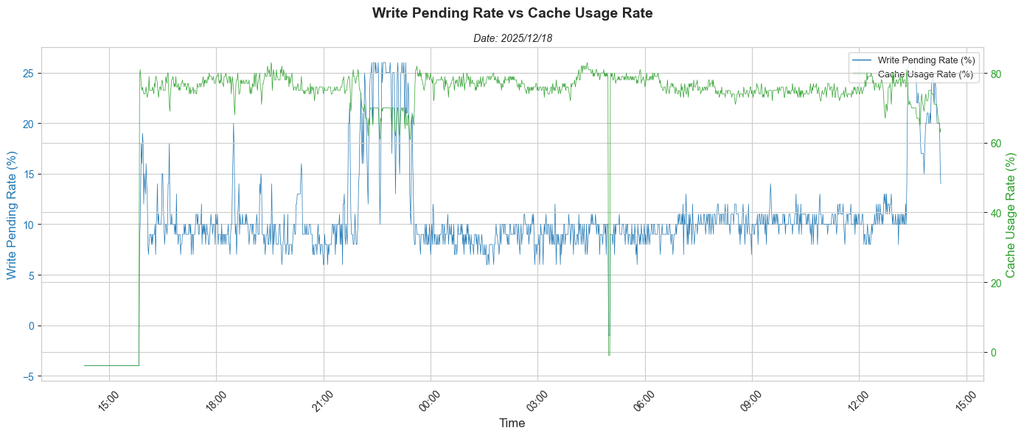

#### 6.1.1 Cache Metrics Analysis

#### .1 Analysis: Cache write pending is associated with high transfer rates on LDEVs. It also causes high MPU usage as the MPs will be busy trying to destage the write data that is coming in. In addition cache usage for read data cache goes down to accomodate for the write data coming in. This may cause higher read response times.

### 6.2 MPU Usage vs Write Pending Rate

```
Saved: /Users/visubramaniam/Downloads/PerformanceExportAnalysis/images/02_mpu_usage.png
```

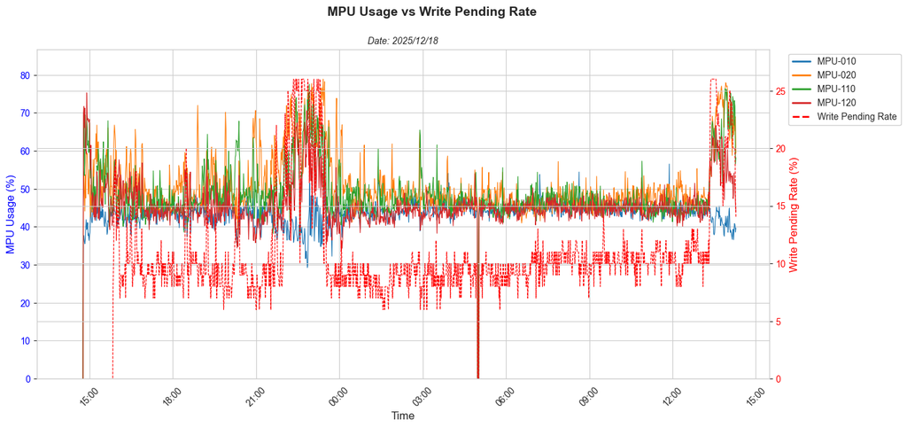

#### 6.2.1 MPU Usage Analysis

#### .1 Analysis: MPU usage can be high owing to high write transfer, high IOPS or background tasks such as UR Journal processing, ShadowImage processing or Thin Image operations.

### 6.3 HIE Metrics: HIE ISW vs MPU HIE

```
Created df_hie_metrics: (1440, 3)
Saved: /Users/visubramaniam/Downloads/PerformanceExportAnalysis/images/03_hie_metrics.png
```

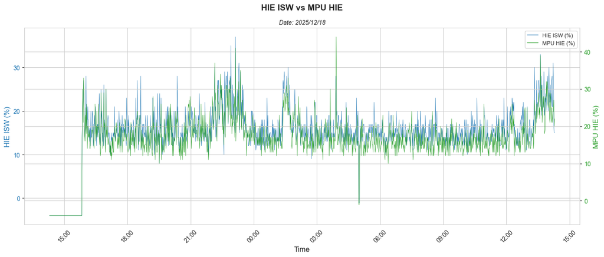

#### 6.3.1 HIE Metrics Analysis

#### .1 Analysis: HIE - ISW and MPU - HIE internal path traffic should not be more than 40% used. At around 40% or more LDEV response times may get affected.

### 6.4 Port Response Time Analysis

```
Saved: /Users/visubramaniam/Downloads/PerformanceExportAnalysis/images/04_port_response.png
```

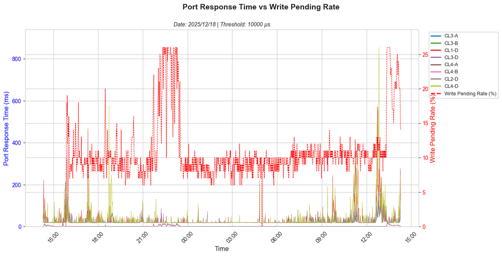

#### 6.4.1 Port Response Analysis

#### .1 Analysis: Port response times are normally high owing to port saturation i.e. high transfer rates or high IOPS. They are also correlated with write pending as high transfer rates may cause high write pending.

### 6.5 LDEV IOPS Analysis

```
Top 5 LDEVs by average IOPS:
  00:00:DD: 4052 IOPS
  00:00:D3: 2603 IOPS
  00:00:DE: 2167 IOPS
  00:00:E8: 1783 IOPS
  00:00:E4: 1361 IOPS
Saved: /Users/visubramaniam/Downloads/PerformanceExportAnalysis/images/05_ldev_iops.png
```

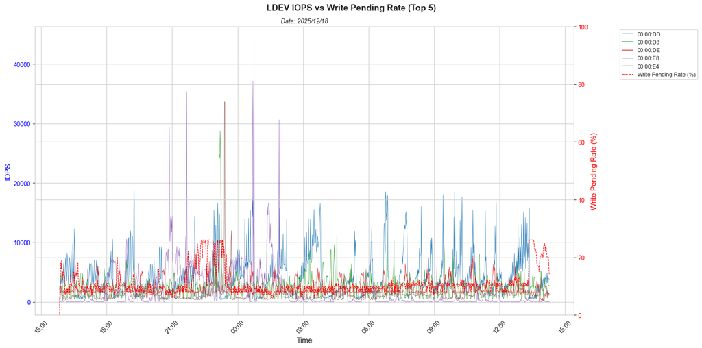

#### 6.5.1 LDEV IOPS Analysis

#### .1 Analysis: LDEVs with high IO activity are identified via a adaptive threshold filter and the top five LDEVs are identified in terms of IOPS. These LDEVs could be causing noisy neighbour issues i.e. hogging all the DP Pool bandwidth, thus starving the other LDEVs of IO bandwidth.

### 6.6 LDEV Transfer Rate Analysis

```
Top 5 LDEVs by average Transfer Rate:
  00:00:EA: 261.8 MB/s
  00:01:71: 195.8 MB/s
  00:00:DD: 159.4 MB/s
  00:00:E8: 95.3 MB/s
  00:01:39: 74.8 MB/s
Saved: /Users/visubramaniam/Downloads/PerformanceExportAnalysis/images/06_ldev_transfer_rate.png
```

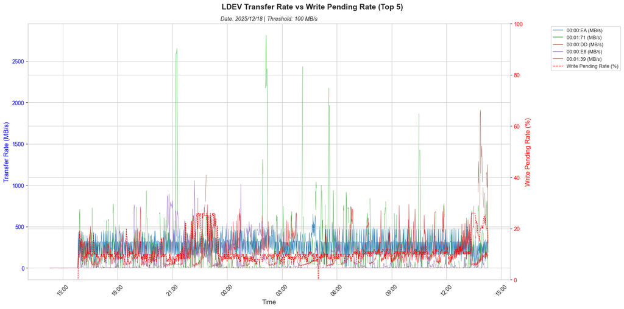

#### 6.6.1 Transfer Rate Analysis

#### .1 Analysis: LDEVs with high transfer rates are typically sequential. Note that the LDEVs identified here may not be the same as the LDEVs identified in Section 6.5. These LDEVs are also identified using a adaptive threshold filter.

### 6.7 LDEV Response Time Analysis

```
Top 5 LDEVs by average Response Time:
  00:01:34: 64080 µs
  00:01:18: 35131 µs
  00:01:52: 28251 µs
  00:01:57: 27427 µs
  00:01:54: 27064 µs
Saved: /Users/visubramaniam/Downloads/PerformanceExportAnalysis/images/07_ldev_response_time.png
```

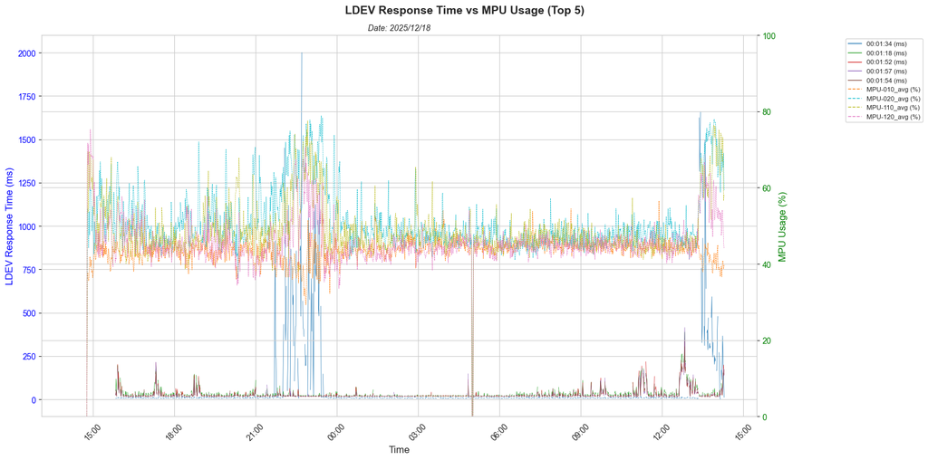

#### 6.7.1 Response Time Analysis

#### .1 Analysis: Here the LDEVs that are affected by high write pending and by high MPU usage are identified. These may not be the same the ones identified earlier. They could be LDEVs that are IO starved.

### 6.8 LDEV Read Hit Analysis

```
LDEVs for Read Hit Analysis: 7
Saved: /Users/visubramaniam/Downloads/PerformanceExportAnalysis/images/08_ldev_read_hit_01_00_00_E8X.png
```

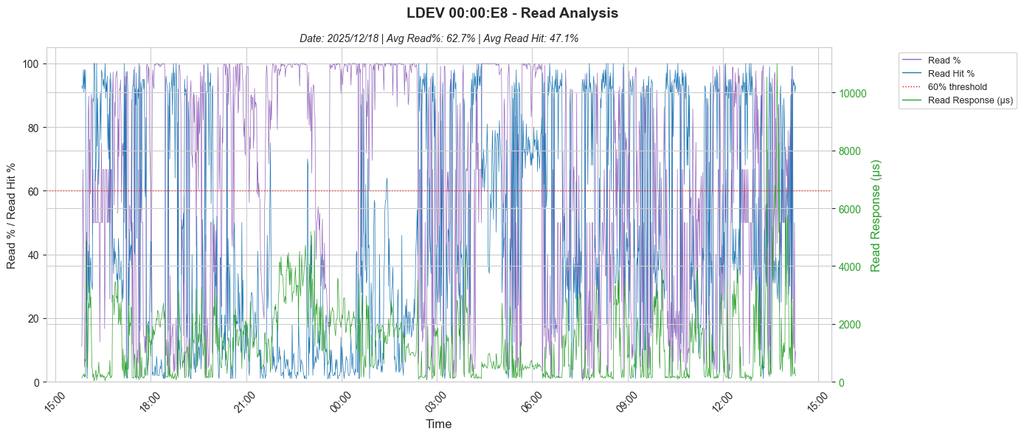

```
--------------------------------------------------------------------------------
Saved: /Users/visubramaniam/Downloads/PerformanceExportAnalysis/images/08_ldev_read_hit_02_00_01_38X.png
```

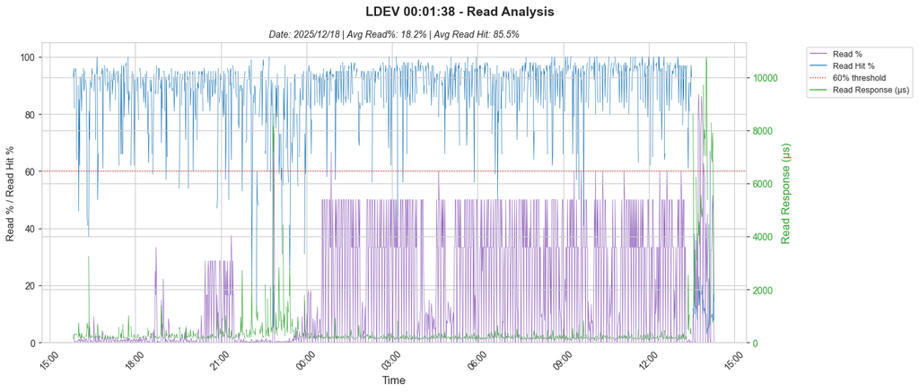

```
--------------------------------------------------------------------------------
Saved: /Users/visubramaniam/Downloads/PerformanceExportAnalysis/images/08_ldev_read_hit_03_00_01_39X.png
```

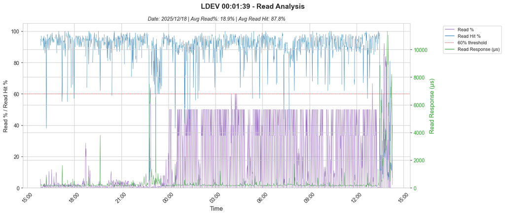

```
--------------------------------------------------------------------------------
Saved: /Users/visubramaniam/Downloads/PerformanceExportAnalysis/images/08_ldev_read_hit_04_00_00_F5X.png
```

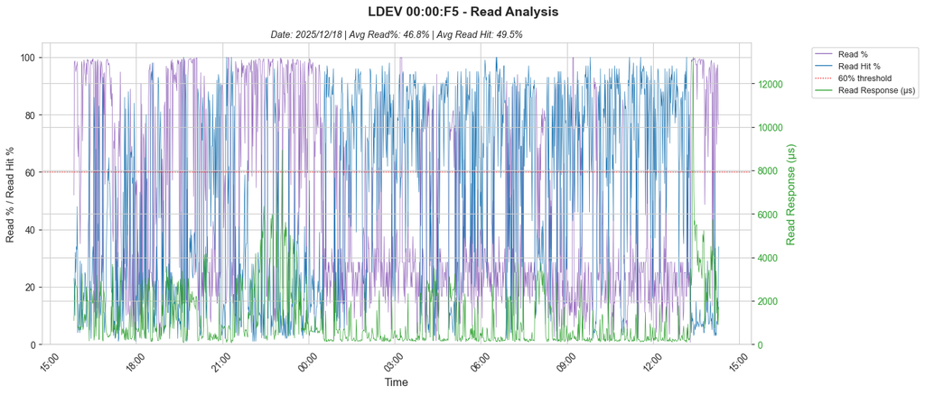

```
--------------------------------------------------------------------------------
Saved: /Users/visubramaniam/Downloads/PerformanceExportAnalysis/images/08_ldev_read_hit_05_00_00_F2X.png
```

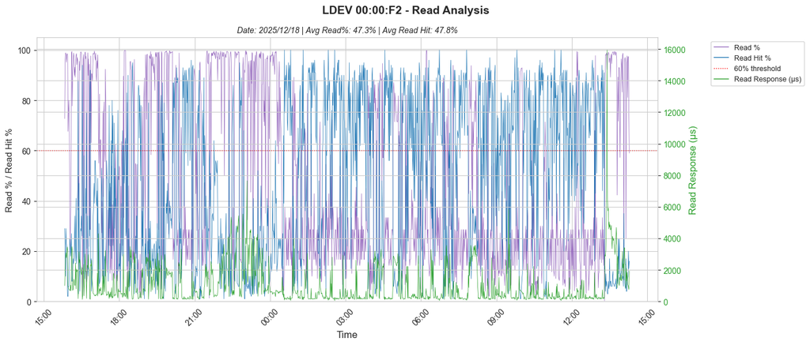

### 6.9 Port IOPS Analysis

```
Saved: /Users/visubramaniam/Downloads/PerformanceExportAnalysis/images/09_port_iops.png
```

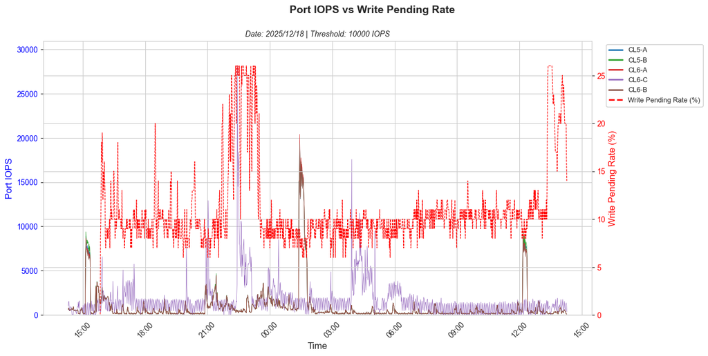

#### 6.9.1 Port IOPS Analysis

#### .1 Analysis: High port IOPS are typically small block random IO. This tends to push MP busy rates or cause write pending issues if mostly write IOPS.

```
Saved: /Users/visubramaniam/Downloads/PerformanceExportAnalysis/images/09b_port_iops_vs_mpu.png
```

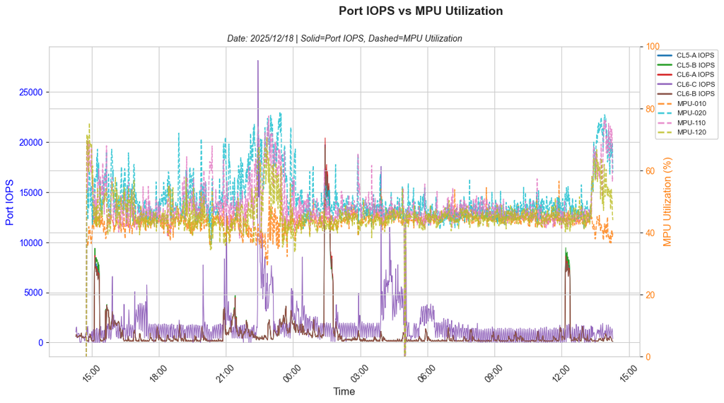

### 6.10 Port Transfer Rate Analysis

```
Saved: /Users/visubramaniam/Downloads/PerformanceExportAnalysis/images/10_port_transfer_rate.png
```

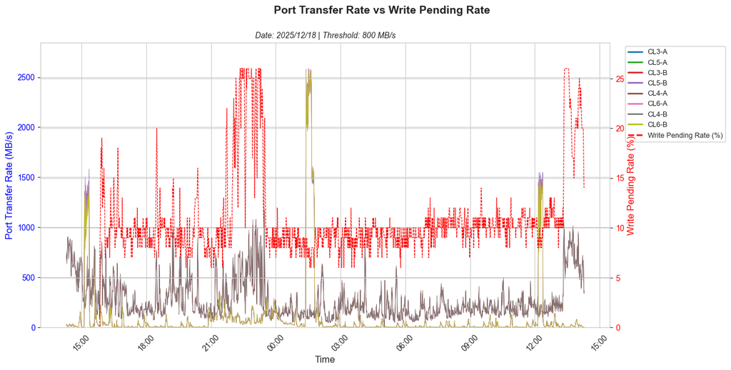

#### 6.10.1 Port Transfer Rate Analysis

#### .1 Analysis: High transfer rate ports will cause LDEV response time issues if the ports are saturated. They will also cause high write pending if the transfer is mostly writes.

## 7. Export Results

Save processed data to CSV files and generate PDF report.

```
  ✓ cache_metrics.csv (1440 rows)
  ✓ hie_metrics.csv (1440 rows)
  ✓ port_response_filtered.csv (1440 rows, 8 ports)
  ✓ ldev_total_iops.csv (1345 rows, 64 LDEVs)
  ✓ ldev_read_pct.csv (1345 rows)

CSV exports complete! 5 files saved to: /Users/visubramaniam/Downloads/PerformanceExportAnalysis/merged
```

### 7.1 Generate PDF Report from Saved Plots

```
Creating professional PDF report with Legal Landscape...
Output file: /Users/visubramaniam/Downloads/PerformanceExportAnalysis/VSP5600_Performance_Report_20260108_085004.pdf
  ✓ Added: 01_cache_metrics.png
  ✓ Added: 02_mpu_usage.png
  ✓ Added: 03_hie_metrics.png
  ✓ Added: 04_port_response.png
  ✓ Added: 05_ldev_iops.png
  ✓ Added: 06_ldev_transfer_rate.png
  ✓ Added: 07_ldev_response_time.png
  ✓ Added: 08_ldev_read_hit_01_00_00_E8X.png
  ✓ Added: 08_ldev_read_hit_02_00_01_38X.png
  ✓ Added: 08_ldev_read_hit_03_00_01_39X.png
  ✓ Added: 08_ldev_read_hit_04_00_00_F5X.png
  ✓ Added: 08_ldev_read_hit_05_00_00_F2X.png
  ✓ Added: 09_port_iops.png
  ✓ Added: 09b_port_iops_vs_mpu.png
  ✓ Added: 10_port_transfer_rate.png

✅ PDF report created successfully!
   File: /Users/visubramaniam/Downloads/PerformanceExportAnalysis/VSP5600_Performance_Report_20260108_085004.pdf
   Total Pages: 16
   Includes: 1 Title Page + 15 Analysis Pages with Charts & Text
```

### 7.2 Export Notebook to HTML

```
✓ nbformat version: 5.10.4
✓ nbconvert version: 7.16.6

============================================================
EXPORT NOTEBOOK TO HTML (FULL NOTEBOOK - NO CODE)
============================================================
  Source: /Users/visubramaniam/Downloads/PerformanceExportAnalysis/VSP5600_Performance_Analysis.ipynb
  Output: /Users/visubramaniam/Downloads/PerformanceExportAnalysis/VSP5600_Performance_Report_20260108_085004.html

============================================================
IMPORTANT: Make sure you have:
  1. Run ALL cells in this notebook
  2. SAVED the notebook (Cmd+S)
============================================================

✓ Notebook loaded (96 cells)
  - Markdown cells: 51
  - Code cells: 45
  - Code cells with outputs: 0

  Converting to HTML...
```

[output not shown]

```
✅ HTML export successful!
   File: /Users/visubramaniam/Downloads/PerformanceExportAnalysis/VSP5600_Performance_Report_20260108_085004.html
   Size: 0.29 MB

============================================================
EXPORT SUMMARY
============================================================
  📄 PDF Report:       VSP5600_Performance_Report_20260108_085004.pdf
  🌐 HTML Report:      VSP5600_Performance_Report_20260108_085004.html
  📁 CSV Files:        /Users/visubramaniam/Downloads/PerformanceExportAnalysis/merged
  🖼️  Plot Images:      /Users/visubramaniam/Downloads/PerformanceExportAnalysis/images
============================================================
```

## Summary

This notebook analyzed the following metrics from the Hitachi VSP5600 storage system:

1. **Cache Metrics** - Write Pending Rate vs Cache Usage Rate
2. **MPU Usage** - Processor utilization across MPU groups
3. **HIE Metrics** - HIE ISW vs MPU HIE
4. **Port Response** - Port response times with high latency detection
5. **LDEV IOPS** - Read/Write IOPS for high-activity LDEVs
6. **LDEV Transfer Rate** - Data throughput analysis
7. **LDEV Response Time** - Latency analysis
8. **LDEV Read Hit** - Cache hit analysis for read-heavy workloads

### Configuration

To analyze a different dataset:

1. Update `ROOT_DIR` to point to your data directory
2. Update `DATA_FOLDER_NAME` to match your extracted folder name
3. Adjust thresholds in the Global Constants section as needed
4. Re-run all cells